# Fertility/Mortality/Internet Usage Analysis

```r
link='https://github.com/aaront002/PUBPOL_542_Group_Project/raw/master/TEAMdata.RDS'
# a RDS file from the web needs:
myFile=url(link)

# reading in data:
fertmortint=readRDS(file = myFile)

# reset indexes to R format:
row.names(fertmortint)=NULL
```

```r
fertmortint
```

| Country | X.InternetUsage | MortalityRate | ContinentCode | CountryCode | FertilityRate |
| --- | --- | --- | --- | --- | --- |
| Albania | 0.11409735 | 103 | EU | ALB | 2.157 |
| Algeria | 0.49170568 | 138 | AF | DZA | 2.514 |
| Andorra | 10.53883561 | 50 | EU | AND | NaN |
| Angola | 0.10504556 | 390 | AF | AGO | 6.639 |
| Antigua and Barbuda | 6.48222574 | 148 | NA | ATG | 2.200 |
| Argentina | 7.03868309 | 92 | SA | ARG | 2.542 |
| Armenia | 1.30047002 | 96 | AS | ARM | 1.648 |
| Armenia | 1.30047002 | 96 | EU | ARM | 1.648 |
| Australia | 46.75611561 | 55 | OC | AUS | 1.756 |
| Austria | 33.73013295 | 63 | EU | AUT | 1.360 |

[output cut: 154 more lines]

Making a new row for adult mortality rate in %

```r
fertmortint$MortalityRate1 = fertmortint$MortalityRate/1000
```

Setting Random Seed

```r
set.seed(999)
```

# Clustering

```r
library(tidyverse)
fertmortint <- fertmortint%>%
  distinct(CountryCode, .keep_all=TRUE)
```

```r
str(fertmortint[,c(2,6,7)])
```

```
## 'data.frame':    158 obs. of  3 variables:
##  $ X.InternetUsage: num  0.114 0.492 10.539 0.105 6.482 ...
##  $ FertilityRate  : num  2.16 2.51 NaN 6.64 2.2 ...
##  $ MortalityRate1 : num  0.103 0.138 0.05 0.39 0.148 0.092 0.096 0.055 0.063 0.122 ...
```

Subsetting the data frame:

```r
dfClus = fertmortint[,c(2,6,7)]

row.names(dfClus)=fertmortint$Country
head(dfClus)
```

|  | X.InternetUsage | FertilityRate | MortalityRate1 |
| --- | --- | --- | --- |
| Albania | 0.1140973 | 2.157 | 0.103 |
| Algeria | 0.4917057 | 2.514 | 0.138 |
| Andorra | 10.5388356 | NaN | 0.050 |
| Angola | 0.1050456 | 6.639 | 0.390 |
| Antigua and Barbuda | 6.4822257 | 2.200 | 0.148 |
| Argentina | 7.0386831 | 2.542 | 0.092 |

Decide distance method and compute distance matrix:

```r
library(cluster)
dfClus_D=cluster::daisy(x=dfClus)
```

```r
NumCluster = 4
res.pam = pam(x=dfClus_D, k = NumCluster, cluster.only = F)

fertmortint$pam = as.factor(res.pam$clustering)
```

```r
fertmortint[fertmortint$pam==1, 'Country']
```

```
##  [1] "Albania"                        "Algeria"
##  [3] "Angola"                         "Armenia"
##  [5] "Azerbaijan"                     "Bangladesh"
##  [7] "Barbados"                       "Belarus"
##  [9] "Benin"                          "Bhutan"
## [11] "Bolivia"                        "Bosnia and Herzegovina"
## [13] "Botswana"                       "Brazil"
## [15] "Burkina Faso"                   "Burundi"
## [17] "Cambodia"                       "Cameroon"
## [19] "Chad"                           "China"
## [21] "Colombia"                       "Comoros"
## [23] "Cote d'Ivoire"                  "Cuba"
## [25] "Djibouti"                       "Ecuador"
## [27] "El Salvador"                    "Equatorial Guinea"
## [29] "Eritrea"                        "Ethiopia"
```

[output cut: 34 more lines]

Report Table of clusters:

```r
table(fertmortint$pam)
```

```
##
##  1  2  3  4
## 97 31 14 16
```

Report Average Silhouettes:

```r
library(factoextra)
```

```
##   cluster size ave.sil.width
## 1       1   97          0.62
## 2       2   31          0.56
## 3       3   14          0.70
## 4       4   16          0.39
```

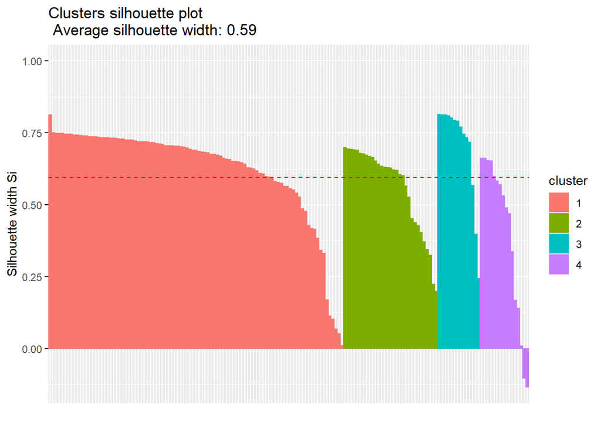

```r
fviz_silhouette(res.pam)
```

Save individual silhouettes:

```r
pamEval= data.frame(res.pam$silinfo$widths)
head(pamEval)
```

|  | cluster | neighbor | sil_width |
| --- | --- | --- | --- |
| Marshall Islands | 1 | 2 | 0.8130371 |
| Haiti | 1 | 2 | 0.7494337 |
| Djibouti | 1 | 2 | 0.7490879 |
| Samoa | 1 | 2 | 0.7486102 |
| Solomon Islands | 1 | 2 | 0.7482488 |
| Ghana | 1 | 2 | 0.7461523 |

Request Negative Silhouettes:

```r
pamEval[pamEval$sil_width<0,]
```

|  | cluster | neighbor | sil_width |
| --- | --- | --- | --- |
| Cyprus | 4 | 2 | -0.1035539 |
| Slovenia | 4 | 2 | -0.1337961 |

### Agglomerative(Agnes)

```r
res.agnes= hcut(dfClus_D, k = NumCluster, isdiss=T,
                hc_func = 'agnes',
                hc_method = "ward.D2")
fertmortint$agn=as.factor(res.agnes$cluster)
fertmortint[fertmortint$agn ==1, 'Country']
```

```
##  [1] "Albania"                        "Algeria"
##  [3] "Angola"                         "Armenia"
##  [5] "Azerbaijan"                     "Bangladesh"
##  [7] "Barbados"                       "Belarus"
##  [9] "Benin"                          "Bhutan"
## [11] "Bolivia"                        "Bosnia and Herzegovina"
## [13] "Botswana"                       "Brazil"
## [15] "Burkina Faso"                   "Burundi"
## [17] "Cambodia"                       "Cameroon"
## [19] "Chad"                           "China"
## [21] "Colombia"                       "Comoros"
## [23] "Cote d'Ivoire"                  "Cuba"
## [25] "Djibouti"                       "Ecuador"
## [27] "El Salvador"                    "Equatorial Guinea"
## [29] "Eritrea"                        "Ethiopia"
```

[output cut: 33 more lines]

```r
table(fertmortint$agn)
```

```
##
##  1  2  3  4
## 96 37 15 10
```

Dendogram:

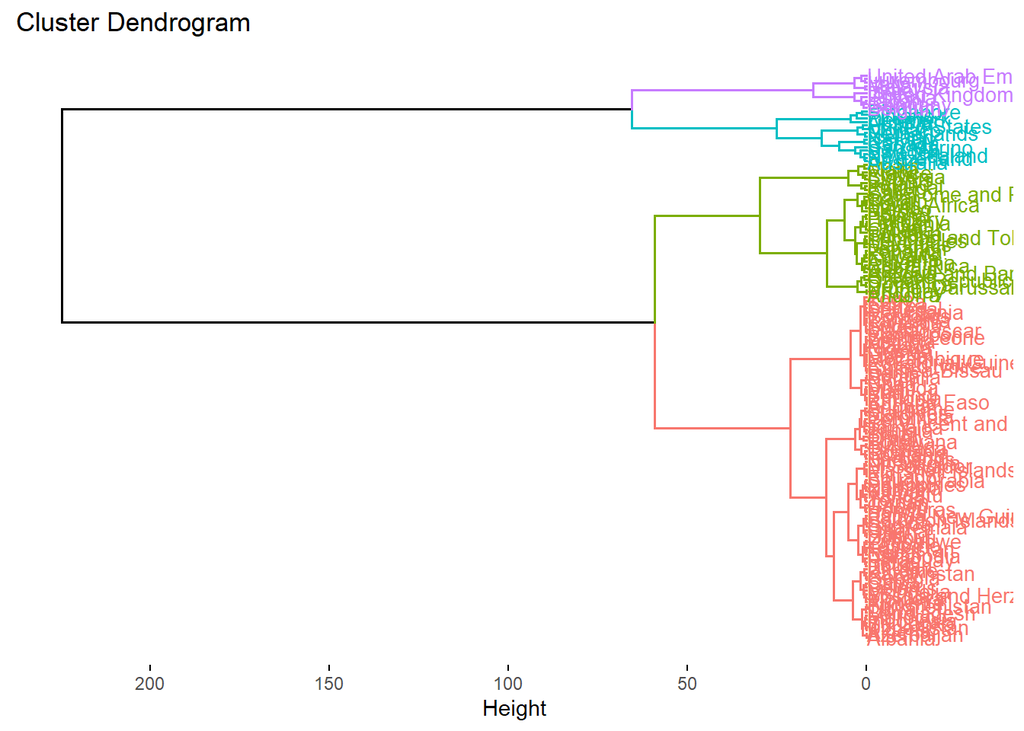

```r
fviz_dend(res.agnes, k=NumCluster, cex = 0.7, horiz = T)
```

Average Silhouettes:

```
##   cluster size ave.sil.width
## 1       1   96          0.68
## 2       2   37          0.38
## 3       3   15          0.58
## 4       4   10          0.69
```

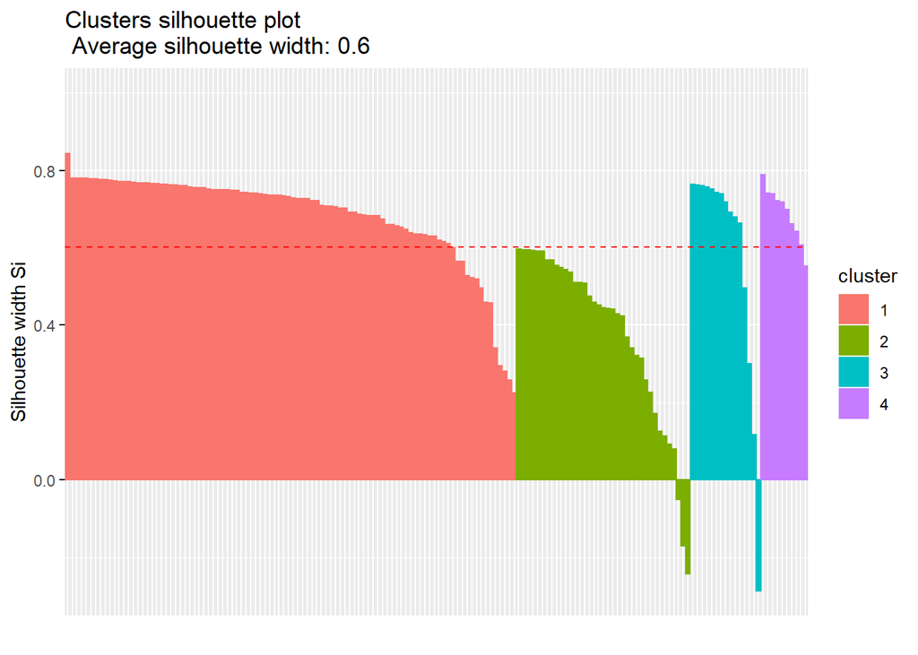

```r
fviz_silhouette(res.agnes)
```

Saving silhouettes:

```r
agnEval = data.frame(res.agnes$silinfo$widths)
head(agnEval)
```

|  | cluster | neighbor | sil_width |
| --- | --- | --- | --- |
| Marshall Islands | 1 | 2 | 0.8432106 |
| Haiti | 1 | 2 | 0.7804752 |
| Samoa | 1 | 2 | 0.7802757 |
| Djibouti | 1 | 2 | 0.7798191 |
| Solomon Islands | 1 | 2 | 0.7792917 |
| Nepal | 1 | 2 | 0.7775981 |

Requesting negative silhouettes:

```r
agnEval[agnEval$sil_width<0,]
```

|  | cluster | neighbor | sil_width |
| --- | --- | --- | --- |
| Qatar | 2 | 1 | -0.05102043 |
| Ireland | 2 | 4 | -0.17058122 |
| Sao Tome and Principe | 2 | 1 | -0.24363518 |
| Austria | 3 | 4 | -0.28684756 |

### Divisive (Diana)

```r
res.diana= hcut(dfClus_D, k = NumCluster,
                hc_func='diana',
                hc_method = "ward.D")

fertmortint$dia=as.factor(res.diana$cluster)

fertmortint[fertmortint$dia==1, 'Country']
```

```
##  [1] "Albania"                        "Algeria"
##  [3] "Angola"                         "Armenia"
##  [5] "Azerbaijan"                     "Bangladesh"
##  [7] "Barbados"                       "Belarus"
##  [9] "Benin"                          "Bhutan"
## [11] "Bolivia"                        "Bosnia and Herzegovina"
## [13] "Botswana"                       "Brazil"
## [15] "Burkina Faso"                   "Burundi"
## [17] "Cambodia"                       "Cameroon"
## [19] "Chad"                           "China"
## [21] "Colombia"                       "Comoros"
## [23] "Cote d'Ivoire"                  "Cuba"
## [25] "Djibouti"                       "Ecuador"
## [27] "El Salvador"                    "Equatorial Guinea"
## [29] "Eritrea"                        "Ethiopia"
```

[output cut: 34 more lines]

```r
table(fertmortint$dia)
```

```
##
##  1  2  3  4
## 98 35 13 12
```

Dendogram:

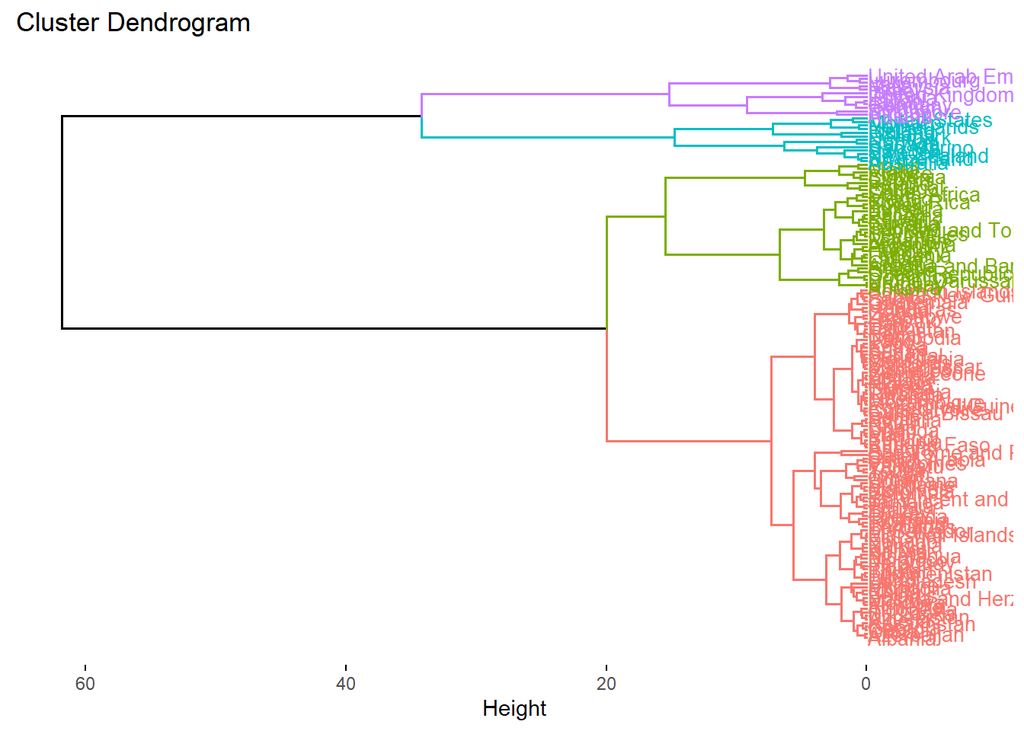

```r
fviz_dend(res.diana,k=NumCluster, cex = 0.7, horiz =T)
```

Average Silhouettes:

```
##   cluster size ave.sil.width
## 1       1   98          0.68
## 2       2   35          0.42
## 3       3   13          0.68
## 4       4   12          0.56
```

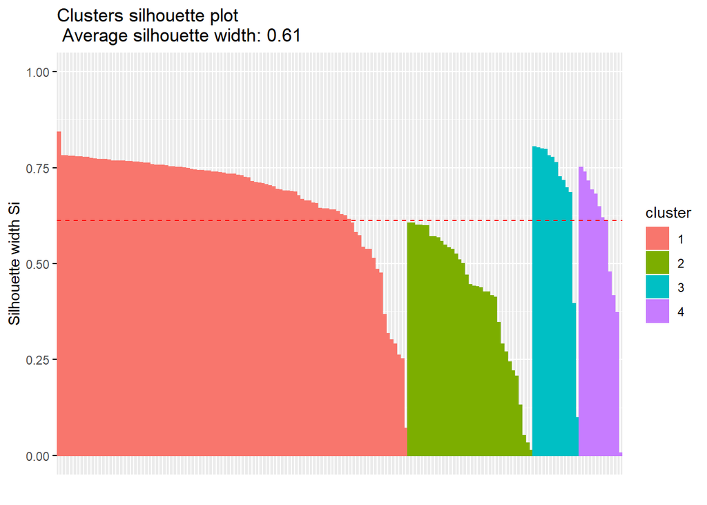

```r
fviz_silhouette(res.diana)
```

Detecting Anomalies:

```r
diaEval = data.frame(res.diana$silinfo$widths)
head(diaEval)
```

|  | cluster | neighbor | sil_width |
| --- | --- | --- | --- |
| Marshall Islands | 1 | 2 | 0.8423532 |
| Samoa | 1 | 2 | 0.7810185 |
| Haiti | 1 | 2 | 0.7805600 |
| Solomon Islands | 1 | 2 | 0.7799702 |
| Djibouti | 1 | 2 | 0.7799187 |
| Guatemala | 1 | 2 | 0.7787263 |

```r
diaEval[diaEval$sil_width<0,]
```

| cluster | neighbor | sil_width |
| --- | --- | --- |

TESTING 3 Clusters:

```r
#res.diana= hcut(dfClus_D, k = 3,
                #hc_func='diana',
                #hc_method = "ward.D")

#fertmortint$dia=as.factor(res.diana$cluster)

#fertmortint[fertmortint$dia==1, 'Country']

#fviz_dend(res.diana,k=3, cex = 0.7, horiz =T)

#fviz_silhouette(res.diana)
```

TESTING 5 Clusters:

```r
#res.diana= hcut(dfClus_D, k = 5,
                #hc_func='diana',
                #hc_method = "ward.D")

#fertmortint$dia=as.factor(res.diana$cluster)

#fertmortint[fertmortint$dia==1, 'Country']

#fviz_dend(res.diana,k=5, cex = 0.7, horiz =T)

#fviz_silhouette(res.diana)
```

### Density Based Clustering

```r
library(dbscan)
```

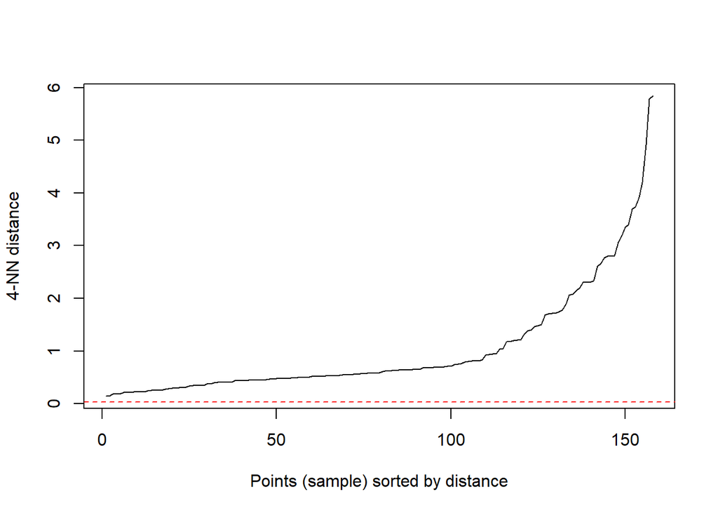

```r
minNeighs = 4
kNNdistplot(dfClus_D, k = minNeighs)
abline(h=.03, col = "red", lty=2)
```

```r
distance = 1.5
res.db=dbscan::dbscan(dfClus_D, eps=distance, minPts=minNeighs)

res.db
```

```
## DBSCAN clustering for 158 objects.
## Parameters: eps = 1.5, minPts = 4
## The clustering contains 4 cluster(s) and 13 noise points.
##
##   0   1   2   3   4
##  13 125   8   4   8
##
## Available fields: cluster, eps, minPts
```

```r
fertmortint$db=as.factor(res.db$cluster)
```

## Comparing Clustering

```r
projectedData = cmdscale(dfClus_D, k=2)

#saving coordinates to original data frame:
fertmortint$dim1 = projectedData[,1]
fertmortint$dim2 = projectedData[,2]
```

Viewing the Map:

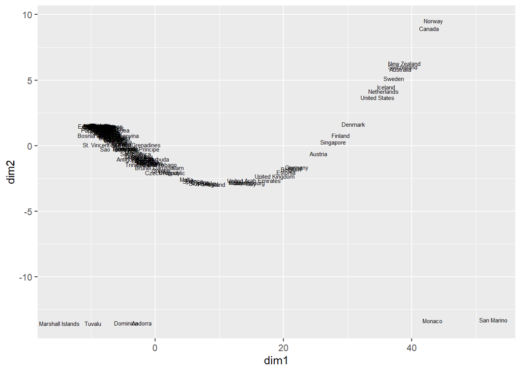

```r
base = ggplot(data=fertmortint,
              aes(x=dim1, y=dim2,
                  label=Country))
base + geom_text(size = 2)
```

Plot results from PAM:

```r
pamPlot = base+labs(title = "PAM") + geom_point(size=2,
                                                aes(color=pam),
                                                show.legend =F)
```

Plot results from AGNES:

```r
agnPlot = base+labs(title = "AGNES") + geom_point(size=2,
                                                aes(color=agn),
                                                show.legend =F)
```

Plot results from DIANA:

```r
diaPlot = base+labs(title = "DIANA") + geom_point(size=2,
                                                aes(color=dia),
                                                show.legend =F)
```

Ploting results from DBSCAN:

```r
dbPlot = base + labs(title = "DBSCAN") + geom_point(size =2,
                                                    aes(color=db),
                                                    show.legend = F)
```

Visual Comparison:

```r
library(ggpubr)
```

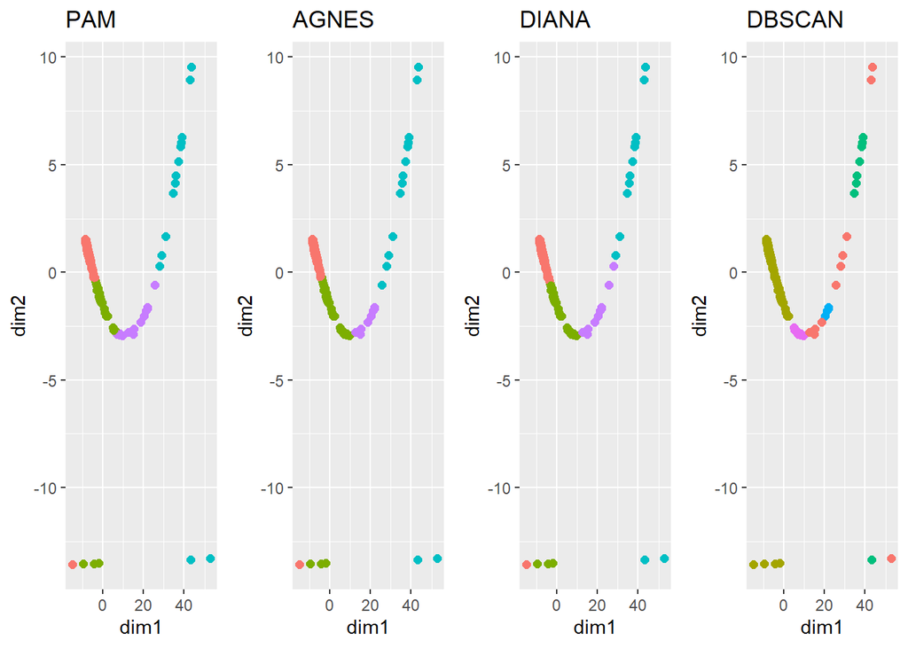

```r
ggarrange(pamPlot, agnPlot, diaPlot, dbPlot,ncol = 4)
```

Ploting results from DBSCAN:

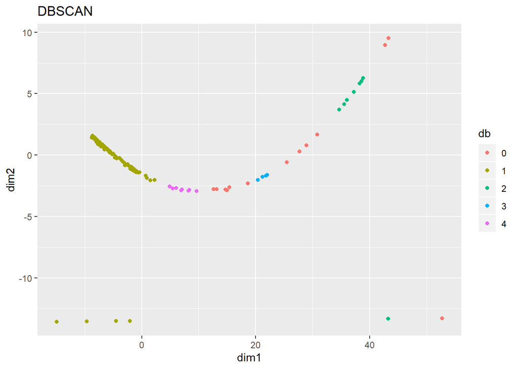

```r
dbPlot = base + labs(title = "DBSCAN") + geom_point(aes(color=db), show.legend = T)

dbPlot
```

Checking the mean values of the clusters:

```r
aggregate(data=fertmortint,MortalityRate1 ~ db,FUN=mean)
```

| db | MortalityRate1 |
| --- | --- |
| 0 | 0.06623077 |
| 1 | 0.21788800 |
| 2 | 0.06250000 |
| 3 | 0.07500000 |
| 4 | 0.06200000 |

```r
aggregate(data=fertmortint,FertilityRate ~ db,FUN=mean)
```

| db | FertilityRate |
| --- | --- |
| 0 | 1.903000 |
| 1 | 3.654769 |
| 2 | 1.804571 |
| 3 | 1.442250 |
| 4 | 1.657625 |

```r
aggregate(data=fertmortint,X.InternetUsage ~ db,FUN=mean)
```

| db | X.InternetUsage |
| --- | --- |
| 0 | 33.611869 |
| 1 | 2.417138 |
| 2 | 45.080279 |
| 3 | 29.553933 |
| 4 | 15.286648 |

# Regression Analysis

```r
fertmortint$MortalityRate2 = fertmortint$MortalityRate1*fertmortint$MortalityRate1
```

Hypotheses:

```r
hypo1=formula(FertilityRate~ MortalityRate1 + X.InternetUsage)
hypo2=formula(FertilityRate~ MortalityRate1 + X.InternetUsage + ContinentCode)
hypo3=formula(FertilityRate~ MortalityRate1 + MortalityRate2 + X.InternetUsage)
hypo4=formula(FertilityRate~ MortalityRate1 + MortalityRate2 + X.InternetUsage + ContinentCode)
```

Checking the variables in the hypotheses:

```r
str(fertmortint)
```

```
## 'data.frame':    158 obs. of  14 variables:
##  $ Country        : chr  "Albania" "Algeria" "Andorra" "Angola" ...
##  $ X.InternetUsage: num  0.114 0.492 10.539 0.105 6.482 ...
##  $ MortalityRate  : int  103 138 50 390 148 92 96 55 63 122 ...
##  $ ContinentCode  : chr  "EU" "AF" "EU" "AF" ...
##  $ CountryCode    : chr  "ALB" "DZA" "AND" "AGO" ...
##  $ FertilityRate  : num  2.16 2.51 NaN 6.64 2.2 ...
##  $ MortalityRate1 : num  0.103 0.138 0.05 0.39 0.148 0.092 0.096 0.055 0.063 0.122 ...
##  $ pam            : Factor w/ 4 levels "1","2","3","4": 1 1 2 1 2 2 1 3 4 1 ...
##  $ agn            : Factor w/ 4 levels "1","2","3","4": 1 1 2 1 2 2 1 3 3 1 ...
##  $ dia            : Factor w/ 4 levels "1","2","3","4": 1 1 2 1 2 2 1 3 4 1 ...
##  $ db             : Factor w/ 5 levels "0","1","2","3",..: 2 2 2 2 2 2 2 3 1 2 ...
##  $ dim1           : num  -8.36 -8 -2.06 -8.61 -1.87 ...
##  $ dim2           : num  1.32 1.2 -13.52 1.47 -1.03 ...
##  $ MortalityRate2 : num  0.0106 0.019 0.0025 0.1521 0.0219 ...
```

Create regression models:

```r
reg1=glm(hypo1,data = fertmortint)
reg2=glm(hypo2,data = fertmortint)
reg3=glm(hypo3,data = fertmortint)
reg4=glm(hypo4,data = fertmortint)
```

Summary of results:

```r
summary(reg1)
```

```
##
## Call:
## glm(formula = hypo1, data = fertmortint)
##
## Deviance Residuals:
##     Min       1Q   Median       3Q      Max
## -4.2828  -0.6815  -0.0514   0.6445   3.4965
##
## Coefficients:
##                  Estimate Std. Error t value Pr(>|t|)
## (Intercept)      1.952082   0.193779  10.074  < 2e-16 ***
## MortalityRate1   7.968935   0.699888  11.386  < 2e-16 ***
## X.InternetUsage -0.023699   0.007902  -2.999  0.00317 **
## ---
## Signif. codes:  0 '***' 0.001 '**' 0.01 '*' 0.05 '.' 0.1 ' ' 1
##
## (Dispersion parameter for gaussian family taken to be 1.251699)
##
##     Null deviance: 457.13  on 151  degrees of freedom
## Residual deviance: 186.50  on 149  degrees of freedom
##   (6 observations deleted due to missingness)
## AIC: 470.45
##
## Number of Fisher Scoring iterations: 2
```

```r
summary(reg2)
```

```
##
## Call:
## glm(formula = hypo2, data = fertmortint)
##
## Deviance Residuals:
##      Min        1Q    Median        3Q       Max
## -3.10750  -0.47496   0.03344   0.60555   2.74728
##
## Coefficients:
##                 Estimate Std. Error t value Pr(>|t|)
## (Intercept)      3.85351    0.33674  11.444  < 2e-16 ***
## MortalityRate1   3.85245    0.85469   4.507 1.35e-05 ***
## X.InternetUsage -0.01328    0.00728  -1.825 0.070098 .
## ContinentCodeAS -1.57149    0.28508  -5.512 1.59e-07 ***
## ContinentCodeEU -2.39473    0.32253  -7.425 9.08e-12 ***
## ContinentCodeNA -1.50730    0.32489  -4.639 7.78e-06 ***
## ContinentCodeOC -0.62563    0.38352  -1.631 0.105014
## ContinentCodeSA -1.44093    0.37249  -3.868 0.000165 ***
## ---
## Signif. codes:  0 '***' 0.001 '**' 0.01 '*' 0.05 '.' 0.1 ' ' 1
##
## (Dispersion parameter for gaussian family taken to be 0.9090321)
##
##     Null deviance: 457.13  on 151  degrees of freedom
## Residual deviance: 130.90  on 144  degrees of freedom
##   (6 observations deleted due to missingness)
## AIC: 426.64
##
## Number of Fisher Scoring iterations: 2
```

```r
summary(reg3)
```

```
##
## Call:
## glm(formula = hypo3, data = fertmortint)
##
## Deviance Residuals:
##     Min       1Q   Median       3Q      Max
## -2.5419  -0.5678  -0.0153   0.5185   2.7635
##
## Coefficients:
##                   Estimate Std. Error t value Pr(>|t|)
## (Intercept)       0.095198   0.271473   0.351    0.726
## MortalityRate1   24.374029   2.023712  12.044  < 2e-16 ***
## MortalityRate2  -25.567475   3.023236  -8.457 2.42e-14 ***
## X.InternetUsage   0.003069   0.007238   0.424    0.672
## ---
## Signif. codes:  0 '***' 0.001 '**' 0.01 '*' 0.05 '.' 0.1 ' ' 1
##
## (Dispersion parameter for gaussian family taken to be 0.8495925)
##
##     Null deviance: 457.13  on 151  degrees of freedom
## Residual deviance: 125.74  on 148  degrees of freedom
##   (6 observations deleted due to missingness)
## AIC: 412.53
##
## Number of Fisher Scoring iterations: 2
```

```r
summary(reg4)
```

```
##
## Call:
## glm(formula = hypo4, data = fertmortint)
##
## Deviance Residuals:
##      Min        1Q    Median        3Q       Max
## -2.78180  -0.56153   0.06614   0.45586   2.42780
##
## Coefficients:
##                   Estimate Std. Error t value Pr(>|t|)
## (Intercept)       1.872137   0.427779   4.376 2.31e-05 ***
## MortalityRate1   17.450006   2.240804   7.787 1.26e-12 ***
## MortalityRate2  -19.223314   2.982669  -6.445 1.66e-09 ***
## X.InternetUsage   0.004692   0.007010   0.669  0.50435
## ContinentCodeAS  -1.074269   0.263381  -4.079 7.49e-05 ***
## ContinentCodeEU  -1.715911   0.303758  -5.649 8.43e-08 ***
## ContinentCodeNA  -1.051267   0.295589  -3.557  0.00051 ***
## ContinentCodeOC  -0.474914   0.339593  -1.398  0.16413
## ContinentCodeSA  -0.919237   0.338857  -2.713  0.00749 **
## ---
## Signif. codes:  0 '***' 0.001 '**' 0.01 '*' 0.05 '.' 0.1 ' ' 1
##
## (Dispersion parameter for gaussian family taken to be 0.7093421)
##
##     Null deviance: 457.13  on 151  degrees of freedom
## Residual deviance: 101.44  on 143  degrees of freedom
##   (6 observations deleted due to missingness)
## AIC: 389.88
##
## Number of Fisher Scoring iterations: 2
```

Comparing the four models:

```r
anova(reg1,reg2,reg3,reg4,test="Chisq")
```

|  | Resid. Df | Resid. Dev | Df | Deviance | Pr(>Chi) |
| --- | --- | --- | --- | --- | --- |
| 1 | 149 | 186.5031 | NA | NA | NA |
| 2 | 144 | 130.9006 | 5 | 55.602481 | 1.825523e-15 |
| 3 | 148 | 125.7397 | -4 | 5.160934 | NA |
| 4 | 143 | 101.4359 | 5 | 24.303775 | 2.111062e-06 |

```r
library(rsq)
```

Compare the R-squared values of the models:

```r
rsq(reg1,adj=T)
```

```
## [1] 0.5865326
```

```r
rsq(reg2,adj=T)
```

```
## [1] 0.699724
```

```r
rsq(reg3,adj=T)
```

```
## [1] 0.7193583
```

```r
rsq(reg4,adj=T)
```

```
## [1] 0.7656866
```

## Checking the assumptions of Hypothesis 2

Linearity between dependent variable and predictors should follow a linear, horizontal trend:

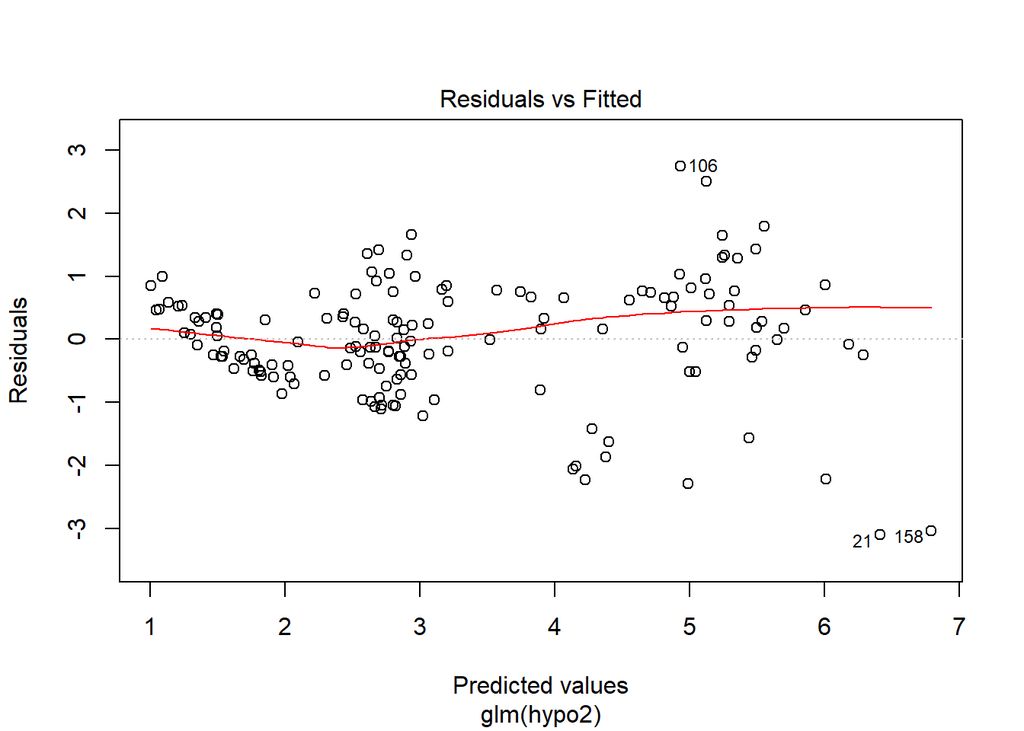

```r
plot(reg2,1)
```

Normality of residuals is assumed:

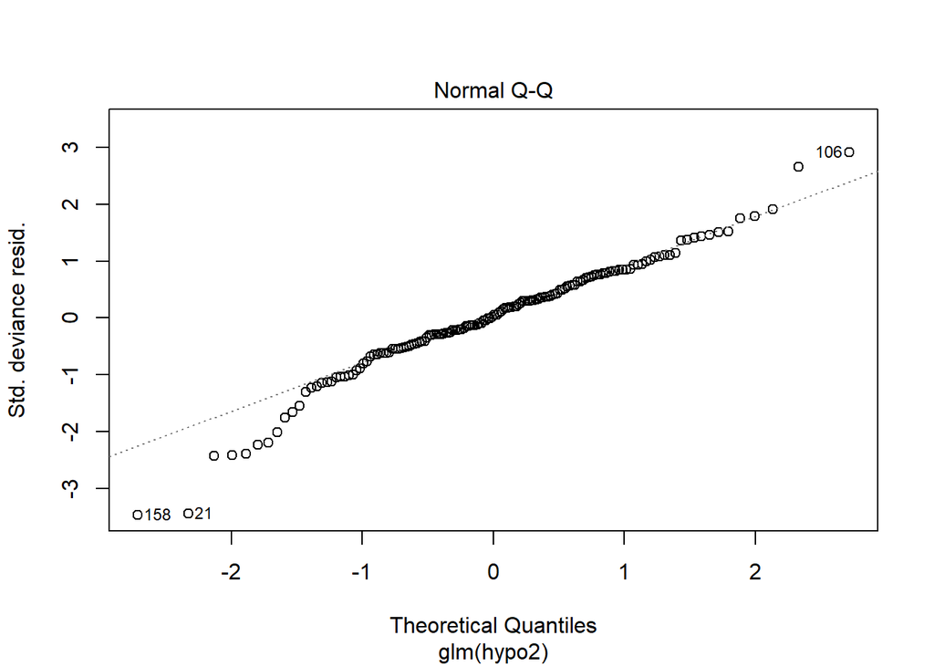

```r
plot(reg2,2)
```

Mathematical check of normality:

```r
shapiro.test(reg2$residuals)
```

```
##
##  Shapiro-Wilk normality test
##
## data:  reg2$residuals
## W = 0.97061, p-value = 0.002436
```

Checking homoskedasticity assumption:

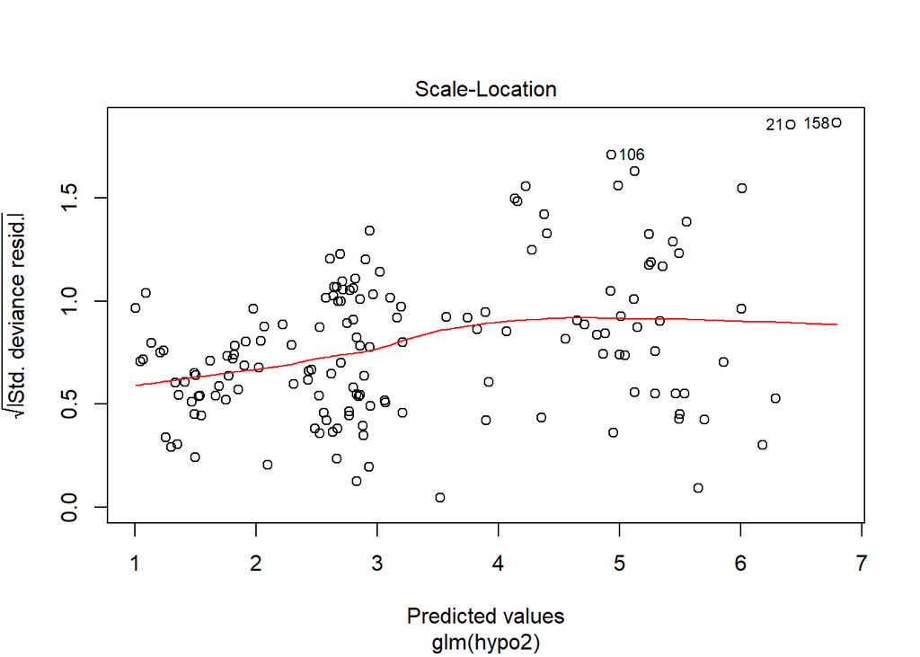

```r
plot(reg2, 3)
```

```r
library(lmtest)
```

Mathematical exploration of homoskedascity:

```r
bptest(reg2)
```

```
##
##  studentized Breusch-Pagan test
##
## data:  reg2
## BP = 32.659, df = 7, p-value = 3.065e-05
```

```r
library(car)
```

We assume that the predictors are not correlated:

```r
#lower than 5 is desirable
vif(reg2)
```

```
##                     GVIF Df GVIF^(1/(2*Df))
## MortalityRate1  2.609118  1        1.615277
## X.InternetUsage 1.485141  1        1.218663
## ContinentCode   2.849591  5        1.110397
```

Analyze the effect of atypical values. Determine if outliers (points that are far from the rest, but still in the trend) or high-leverage points (far from the trend but close to the rest) are influential. Visual exploration:

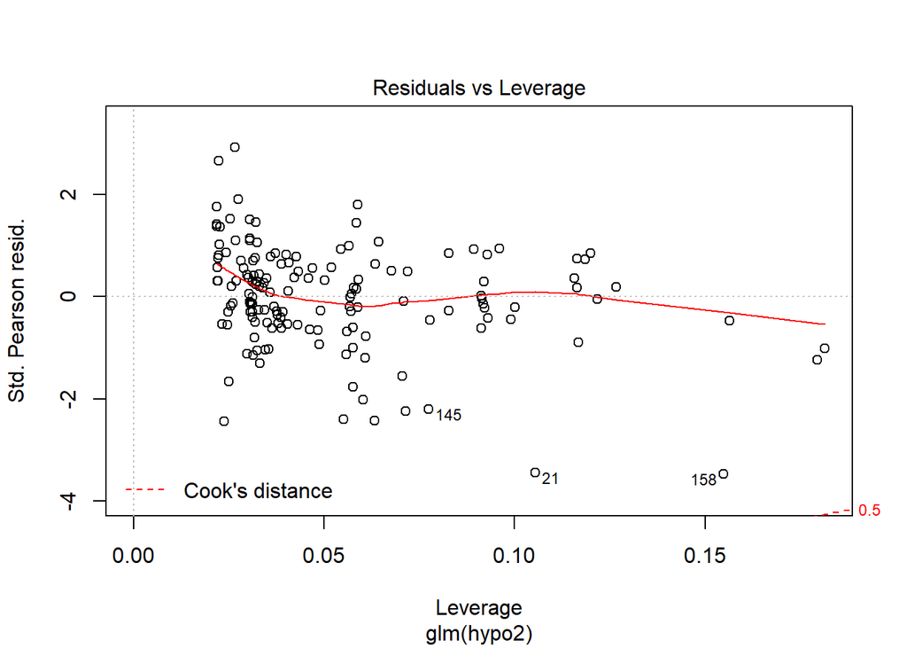

```r
plot(reg2,5)
```

Querying:

```r
regInf=as.data.frame(influence.measures(reg2)$is.inf)
regInf[regInf$cook.d,]
```

| dfb.1_ | dfb.MrR1 | dfb.X.IU | dfb.CCAS | dfb.CCEU | dfb.CCNA | dfb.CCOC | dfb.CCSA | dffit | cov.r | cook.d | hat |
| --- | --- | --- | --- | --- | --- | --- | --- | --- | --- | --- | --- |

Summary plot of work:

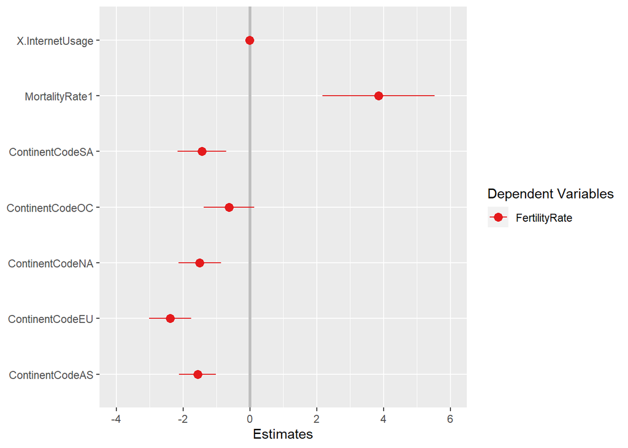

```r
library(sjPlot)
plot_models(reg2,vline.color = "grey")
```

## Predictive Approach with Hypothesis 2

Split the data set:

```r
library(caret)
newdata <- na.omit(fertmortint)
```

```r
set.seed(123)

selection = createDataPartition(newdata$FertilityRate,
                                p = 0.75,
                                list = FALSE
                                )

trainReg = newdata[ selection, ]

testReg  = newdata[-selection, ]
```

Regress with train data: Use cross validation, applying the regression to five samples from the training data set:

```r
ctrl = trainControl(method = 'cv',number = 5)

reg2CV = train(hypo2,
                 data = trainReg,
                 method = 'glm',
                 trControl = ctrl)

summary(reg2CV)
```

```
##
## Call:
## NULL
##
## Deviance Residuals:
##      Min        1Q    Median        3Q       Max
## -2.69322  -0.49127   0.09351   0.58491   2.53088
##
## Coefficients:
##                  Estimate Std. Error t value Pr(>|t|)
## (Intercept)      4.187288   0.395023  10.600  < 2e-16 ***
## MortalityRate1   2.755031   0.953188   2.890 0.004653 **
## X.InternetUsage -0.016179   0.008654  -1.870 0.064246 .
## ContinentCodeAS -1.669731   0.332353  -5.024 2.02e-06 ***
## ContinentCodeEU -2.541746   0.382862  -6.639 1.31e-09 ***
## ContinentCodeNA -1.637857   0.366511  -4.469 1.95e-05 ***
## ContinentCodeOC -0.630308   0.494051  -1.276 0.204765
## ContinentCodeSA -1.701093   0.452095  -3.763 0.000274 ***
## ---
## Signif. codes:  0 '***' 0.001 '**' 0.01 '*' 0.05 '.' 0.1 ' ' 1
##
## (Dispersion parameter for gaussian family taken to be 0.9098872)
##
##     Null deviance: 334.072  on 115  degrees of freedom
## Residual deviance:  98.268  on 108  degrees of freedom
## AIC: 327.95
##
## Number of Fisher Scoring iterations: 2
```

Evaluate Performance:

```r
predictedVal<-predict(reg2CV,testReg)

postResample(obs = testReg$FertilityRate, pred=predictedVal)
```

```
##      RMSE  Rsquared       MAE
## 0.9826556 0.7353058 0.7530988
```

## Checking the assumptions of Hypothesis 4

Linearity between dependent variable and predictors should follow a linear, horizontal trend:

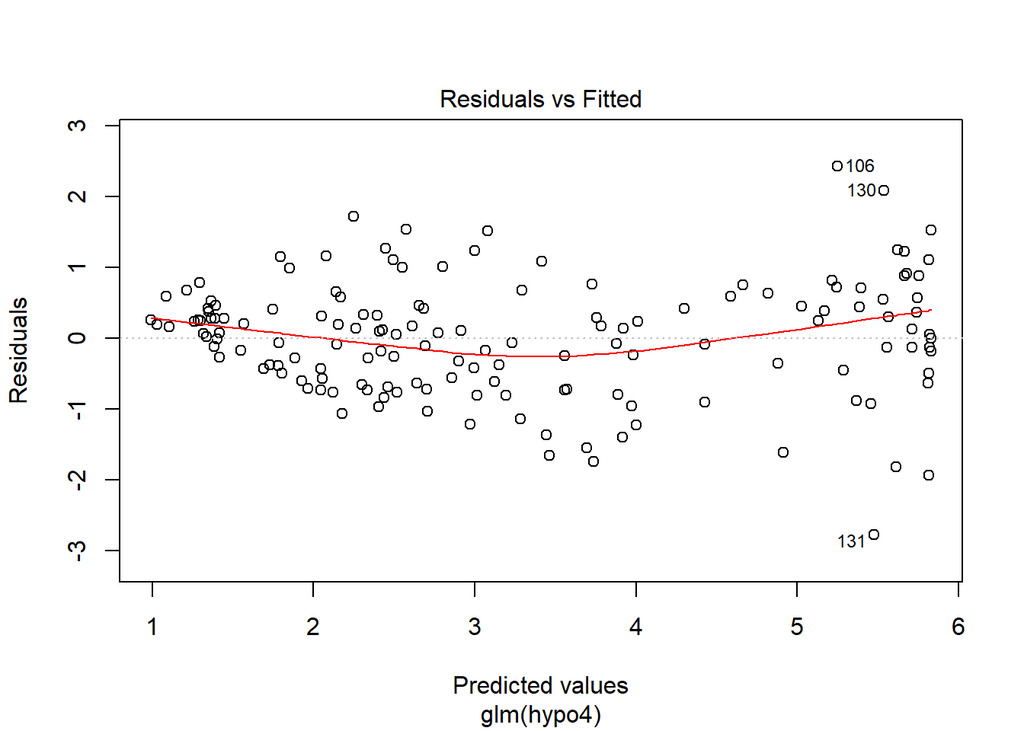

```r
plot(reg4,1)
```

Normality of residuals is assumed:

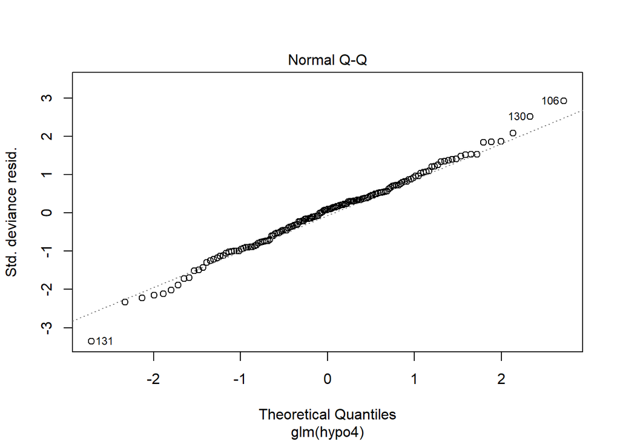

```r
plot(reg4,2)
```

Mathematical check of normality:

```r
shapiro.test(reg4$residuals)
```

```
##
##  Shapiro-Wilk normality test
##
## data:  reg4$residuals
## W = 0.99307, p-value = 0.6783
```

Checking homoskedasticity assumption:

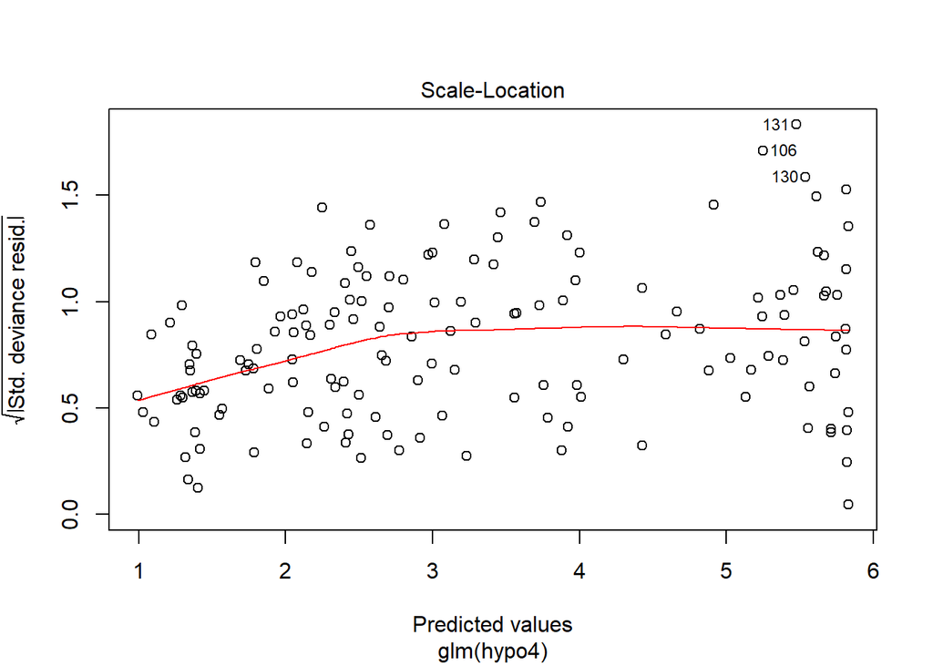

```r
plot(reg4, 3)
```

Mathematical exploration of homoskedascity:

```r
bptest(reg4)
```

```
##
##  studentized Breusch-Pagan test
##
## data:  reg4
## BP = 18.716, df = 8, p-value = 0.01645
```

We assume that the predictors are not correlated:

```r
#lower than 5 is desirable
vif(reg4)
```

```
##                      GVIF Df GVIF^(1/(2*Df))
## MortalityRate1  22.983146  1        4.794074
## MortalityRate2  16.044214  1        4.005523
## X.InternetUsage  1.764529  1        1.328356
## ContinentCode    3.322029  5        1.127562
```

Analyze the effect of atypical values. Determine if outliers (points that are far from the rest, but still in the trend) or high-leverage points (far from the trend but close to the rest) are influential. Visual exploration:

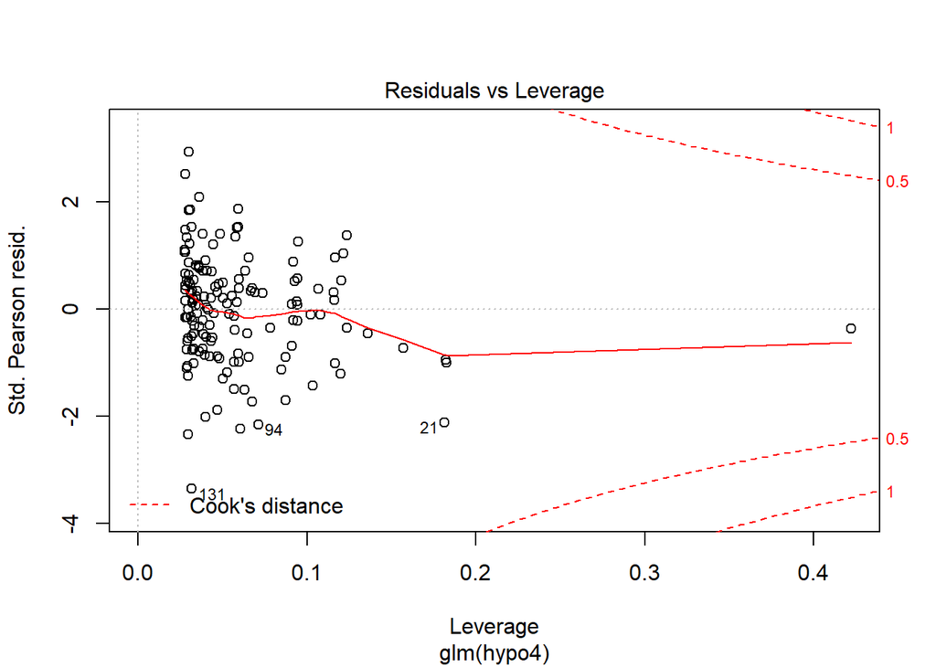

```r
plot(reg4,5)
```

Querying:

```r
regInf2=as.data.frame(influence.measures(reg4)$is.inf)
regInf2[regInf2$cook.d,]
```

| dfb.1_ | dfb.MrR1 | dfb.MrR2 | dfb.X.IU | dfb.CCAS | dfb.CCEU | dfb.CCNA | dfb.CCOC | dfb.CCSA | dffit | cov.r | cook.d | hat |
| --- | --- | --- | --- | --- | --- | --- | --- | --- | --- | --- | --- | --- |

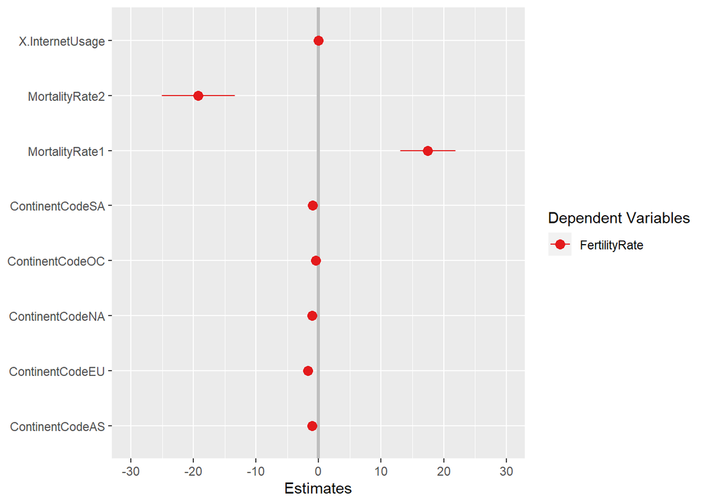

```r
plot_models(reg4,vline.color = "grey")
```

## Predictive Approach with Hypothesis 4

Regress with train data: Use cross validation, applying the regression to five samples from the training data set:

```r
ctrl = trainControl(method = 'cv',number = 5)

reg4CV = train(hypo4,
                 data = trainReg,
                 method = 'glm',
                 trControl = ctrl)

summary(reg4CV)
```

```
##
## Call:
## NULL
##
## Deviance Residuals:
##      Min        1Q    Median        3Q       Max
## -2.71452  -0.51057   0.05104   0.46513   2.15640
##
## Coefficients:
##                   Estimate Std. Error t value Pr(>|t|)
## (Intercept)       2.154889   0.519485   4.148 6.74e-05 ***
## MortalityRate1   15.873550   2.604365   6.095 1.76e-08 ***
## MortalityRate2  -17.654878   3.312427  -5.330 5.50e-07 ***
## X.InternetUsage   0.002775   0.008507   0.326 0.744910
## ContinentCodeAS  -1.096045   0.315731  -3.471 0.000748 ***
## ContinentCodeEU  -1.854045   0.365461  -5.073 1.66e-06 ***
## ContinentCodeNA  -1.079514   0.343678  -3.141 0.002177 **
## ContinentCodeOC  -0.443848   0.442612  -1.003 0.318224
## ContinentCodeSA  -1.195706   0.414742  -2.883 0.004762 **
## ---
## Signif. codes:  0 '***' 0.001 '**' 0.01 '*' 0.05 '.' 0.1 ' ' 1
##
## (Dispersion parameter for gaussian family taken to be 0.7257179)
##
##     Null deviance: 334.072  on 115  degrees of freedom
## Residual deviance:  77.652  on 107  degrees of freedom
## AIC: 302.64
##
## Number of Fisher Scoring iterations: 2
```

Evaluate Performance:

```r
predictedVal<-predict(reg4CV,testReg)

postResample(obs = testReg$FertilityRate, pred=predictedVal)
```

```
##      RMSE  Rsquared       MAE
## 0.8337601 0.8029709 0.6536587
```